# Week 5 - Data Transformation and Visualization

Jacob Martin

West Chester University

## 0.1 Overview

In this weeks exercise, we will demonstrate how to manipulate data that is given in a format that is not ideal. It will be shown how to reshape various data sets, and then join those datasets based off specific columns. Let’s jump in.

## 0.2 Wide Data to Long Data

### 0.2.1 Income Transformation

Let’s start by analyzing the first row of a data set that is in the “wide format”. This data set represents the income made per person, for a country on a given year.

```r
income_pp_wide <- read.csv("income_per_person.csv", header = FALSE)
head(income_pp_wide, 1)
```

```
   V1   V2   V3   V4   V5   V6   V7   V8   V9  V10  V11  V12  V13  V14  V15
1 geo 1800 1801 1802 1803 1804 1805 1806 1807 1808 1809 1810 1811 1812 1813
   V16  V17  V18  V19  V20  V21  V22  V23  V24  V25  V26  V27  V28  V29  V30
1 1814 1815 1816 1817 1818 1819 1820 1821 1822 1823 1824 1825 1826 1827 1828
   V31  V32  V33  V34  V35  V36  V37  V38  V39  V40  V41  V42  V43  V44  V45
1 1829 1830 1831 1832 1833 1834 1835 1836 1837 1838 1839 1840 1841 1842 1843
   V46  V47  V48  V49  V50  V51  V52  V53  V54  V55  V56  V57  V58  V59  V60
1 1844 1845 1846 1847 1848 1849 1850 1851 1852 1853 1854 1855 1856 1857 1858
   V61  V62  V63  V64  V65  V66  V67  V68  V69  V70  V71  V72  V73  V74  V75
1 1859 1860 1861 1862 1863 1864 1865 1866 1867 1868 1869 1870 1871 1872 1873
   V76  V77  V78  V79  V80  V81  V82  V83  V84  V85  V86  V87  V88  V89  V90
1 1874 1875 1876 1877 1878 1879 1880 1881 1882 1883 1884 1885 1886 1887 1888
   V91  V92  V93  V94  V95  V96  V97  V98  V99 V100 V101 V102 V103 V104 V105
1 1889 1890 1891 1892 1893 1894 1895 1896 1897 1898 1899 1900 1901 1902 1903
  V106 V107 V108 V109 V110 V111 V112 V113 V114 V115 V116 V117 V118 V119 V120
1 1904 1905 1906 1907 1908 1909 1910 1911 1912 1913 1914 1915 1916 1917 1918
  V121 V122 V123 V124 V125 V126 V127 V128 V129 V130 V131 V132 V133 V134 V135
1 1919 1920 1921 1922 1923 1924 1925 1926 1927 1928 1929 1930 1931 1932 1933
  V136 V137 V138 V139 V140 V141 V142 V143 V144 V145 V146 V147 V148 V149 V150
1 1934 1935 1936 1937 1938 1939 1940 1941 1942 1943 1944 1945 1946 1947 1948
  V151 V152 V153 V154 V155 V156 V157 V158 V159 V160 V161 V162 V163 V164 V165
1 1949 1950 1951 1952 1953 1954 1955 1956 1957 1958 1959 1960 1961 1962 1963
  V166 V167 V168 V169 V170 V171 V172 V173 V174 V175 V176 V177 V178 V179 V180
1 1964 1965 1966 1967 1968 1969 1970 1971 1972 1973 1974 1975 1976 1977 1978
  V181 V182 V183 V184 V185 V186 V187 V188 V189 V190 V191 V192 V193 V194 V195
1 1979 1980 1981 1982 1983 1984 1985 1986 1987 1988 1989 1990 1991 1992 1993
  V196 V197 V198 V199 V200 V201 V202 V203 V204 V205 V206 V207 V208 V209 V210
1 1994 1995 1996 1997 1998 1999 2000 2001 2002 2003 2004 2005 2006 2007 2008
  V211 V212 V213 V214 V215 V216 V217 V218 V219 V220
1 2009 2010 2011 2012 2013 2014 2015 2016 2017 2018
```

Ugh, what an ugly looking data set. It is clear that this data is large, but also structured strange. In the above dataset, the first column is the `Country`. The first row is `Year`. All other entries are the values for the aforementioned columns & rows.

The objective is to transform this data into a data frame that is longitudinal format. The resulting data set should have three columns:

- Country
- Year
- Income Per Person

First, let’s extract the year, country, and income from the original data set into separate variables.

```r
# Extract the year values from the header row.
years <- income_pp_wide[1,-1]
# Extract the countries.
countries <- income_pp_wide[-1,1]
# Extract the income.
income <- income_pp_wide[-1,-1]
```

Let’s explain what the parameters are doing in this breakdown:

For the `years`, we are taking only the first row, while also dropping the first column and row value in the original data set. This is because that value is literally `geo`, which we can ignore.  
For the `countries` we are taking all values in the first column, while also dropping the first column and row value in the original data set. This is because that value is literally `geo`, which we can ignore.  
For the `income`, we ignore the first row and the first column entirely, while all remaining row & column values are kept.

Furthermore, we can combine the three extracted sets of data and reshape them into a format that is longtitudal.

```r
# Add years as a column.
colnames(income) <- as.character(t(years))

# Make a new dataframe to store everything in.
income_df <- as.data.frame(income)

# Add the countries into the new data frame.
income_df$Country <- countries

# Transform dataframe using `reshape2`.
income_data_long <- reshape2::melt(income_df, id.vars = "Country", variable.name = "Year", value.name = "Income")
```

In the previous code block, the first operation adds year as a column to the income data set. When doing this it is imperative to transpose the `years` as it is in row format.  
From there, we transform the type to an actual data frame.  
Next, the countries and their values are added in as a column to the data frame.

Lastly, a package called `reshape2` it utilized to transform the dataframe into the format we want.

From here we can see the resulting dataset, visualized:

```
              Country Year Income
1         Afghanistan 1800    603
2             Albania 1800    667
3             Algeria 1800    715
4             Andorra 1800   1200
5              Angola 1800    618
6 Antigua and Barbuda 1800    757
```

Success! We have transformed the dataset into a structure that is much more common and easy to work with.

### 0.2.2 Life Expectancy Transformation

From here, we want to perform the same operations on a different data set. The original dataset is structured in an identical manner, but the data itself represents the life expectancy of a person for a given year and country.  
Our transformation process will be identical to the last, so most of the code will look similar. The final output should be a table with the following columns:

- `Country`
- `Year`
- `Life_Expectancy`

```r
life_expectancy_wide <- read.csv("life_expectancy_years.csv", header = FALSE)
# Extract the year values from the header row.
years <- life_expectancy_wide[1,-1]
# Extract the countries.
countries <- life_expectancy_wide[-1,1]
# Extract the life expectancy.
le <- life_expectancy_wide[-1,-1]

# Add years as a column.
colnames(le) <- as.character(t(years))
# Get a dataframe type to work with.
le_df <- as.data.frame(le)
# Add the countries into the data frame.
le_df$Country <- countries

# Make a table in the format we want.
le_data_long <- reshape2::melt(le_df, id.vars = "Country", variable.name = "Year", value.name = "life_expectancy")

# Print the first few rows of the new dataframe
head(le_data_long)
```

```
              Country Year life_expectancy
1         Afghanistan 1800            28.2
2             Albania 1800            35.4
3             Algeria 1800            28.8
4             Andorra 1800              NA
5              Angola 1800            27.0
6 Antigua and Barbuda 1800            33.5
```

Success! We have our data organized in the format we want.

### 0.2.3 Merging Two Datasets

Now that we have two data sets which contain common values in the `country` and `year` columns, we can demonstrate how to join these sets based off their columns and values.

```r
# Merge the income and life_expect data frames
lifexp_income <- merge(income_data_long, le_data_long, by = c("Country", "Year"), all = TRUE)
```

In the above code, we can see the `merge` function takes in 4 arguments.  
The first two are the data sets that were previously transformed.  
The third parameter is about specifying the column(s) we want to join on.  
The the last is how much data we want to take from each set.

```
      Country Year Income life_expectancy
1 Afghanistan 1800    603            28.2
2 Afghanistan 1801    603            28.2
3 Afghanistan 1802    603            28.2
4 Afghanistan 1803    603            28.2
5 Afghanistan 1804    603            28.2
6 Afghanistan 1805    603            28.2
```

Success! Now we have a combined dataset which contains both the income and life expectancy.

### 0.2.4 Region Data Merging

To further expand on our previous combined dataset, we want to add region information.

Consider a new raw dataset:

```
            name alpha.2 alpha.3 country.code    iso_3166.2  region
1    Afghanistan      AF     AFG            4 ISO 3166-2:AF    Asia
2 ��land Islands      AX     ALA          248 ISO 3166-2:AX  Europe
3        Albania      AL     ALB            8 ISO 3166-2:AL  Europe
4        Algeria      DZ     DZA           12 ISO 3166-2:DZ  Africa
5 American Samoa      AS     ASM           16 ISO 3166-2:AS Oceania
6        Andorra      AD     AND           20 ISO 3166-2:AD  Europe
       sub.region intermediate.region region.code sub.region.code
1   Southern Asia                             142              34
2 Northern Europe                             150             154
3 Southern Europe                             150              39
4 Northern Africa                               2              15
5       Polynesia                               9              61
6 Southern Europe                             150              39
  intermediate.region.code
1                       NA
2                       NA
3                       NA
4                       NA
5                       NA
6                       NA
```

While there are many columns, the dataset comes in longitudinal format. There is no need to perform the transformation we demonstrated earlier.

Our objective is to add a `region` column to the previous data set which contains the `income` and `life expectancy`. See the code block below:

```r
lifexp_income_region <- merge(lifexp_income, region_data[, c("name", "region")], by.x = "Country", by.y = "name", all.x = TRUE)
```

It’s important to point out a couple of subtle differences between this merge and the previous merge.  
First, the region data set has `name` as it’s columnar representation of `country`. This is a column we want join on. However, since the names are not identical across both sets, it must be explicitely stated to the function which columns should be joined upon.  
Furthermore, we only want the `region` column to be contained in the new set when joining, so we reduce our region dataset to just `name` and `region` before merging.

The resulting merge is as follows:

```
      Country Year Income life_expectancy region
1 Afghanistan 1949   1030            31.9   Asia
2 Afghanistan 1951   1060            32.4   Asia
3 Afghanistan 1846    660            27.7   Asia
4 Afghanistan 1851    672            27.7   Asia
5 Afghanistan 1848    665            27.7   Asia
6 Afghanistan 1845    658            27.8   Asia
```

Success! We have now added region.

### 0.2.5 Population Transformation

This section starts with a new raw dataset that is in a format which is similar to how the original `income` and the original `life expectancy` datasets were in.

In the code block below, the population dataset is loaded into memory, transformed into longitudinal format, and then merged with our previous cleaned data set to include the `population` metadata. We have displayed how to do each of these steps individually, so all of the steps are condensed into one block.

```r
pop_wide <- read.csv("population_total.csv", header = FALSE)
# Extract the year values from the header row.
years <- pop_wide[1,-1]
# Extract the countries.
countries <- pop_wide[-1,1]
# Extract the population.
pop_raw <- pop_wide[-1,-1]

# Add years as a column.
colnames(pop_raw) <- as.character(t(years))
# Create a new dataframe.
pop_df <- as.data.frame(pop_raw)
# Add the countries into the data frame.
pop_df$Country <- countries

# Reshape the data into longitudinal format.
pop_df_long <- reshape2::melt(pop_df, id.vars = "Country", variable.name = "Year", value.name = "population")

# Merge the population with the cleaned dataset.
final_data_set <- merge(lifexp_income_region, pop_df_long, by = c("Country", "Year"), all = TRUE)

# Print the first few rows of the merged data frame.
head(final_data_set)
```

```
      Country Year Income life_expectancy region population
1 Afghanistan 1800    603            28.2   Asia    3280000
2 Afghanistan 1801    603            28.2   Asia    3280000
3 Afghanistan 1802    603            28.2   Asia    3280000
4 Afghanistan 1803    603            28.2   Asia    3280000
5 Afghanistan 1804    603            28.2   Asia    3280000
6 Afghanistan 1805    603            28.2   Asia    3280000
```

Success! The final data set has a very nice structure to it, populated with correct values!

### 0.2.6 Variables and Observations

To determine how many variables and observations we have, we can simply look at the dimensions of our final data frame.

```
[1] 42924     6
```

There are 6 variables (columns!) and 42924 observations (rows!).

### 0.2.7 Saving Data

Here is a short demonstration of how to pick all rows where `year >= 2000`, and write them to a file.

```r
# Convert the Year column to numeric
final_data_set$Year <- as.numeric(as.character(final_data_set$Year))

# Subset the dataframe to include only rows where Year >= 2000
new_df <- final_data_set[final_data_set$Year >= 2000, ]

write.csv(new_df, "2000data.csv", row.names = FALSE)
```

### 0.2.8 Transformation Summary

In this section we have seen how to work with strange data structures, and turn them into something that is workable and neat.  
There are various means to do transformations, what was shown is here is simply one way to do it. You are encouraged to find your own ways to do transformations so that the conceptual learning process solidifies into a concrete skill.

## 0.3 Graphing using GGPlot

In this section, we will show a scatter plot based off two numerical variables:

- Income
- Life Expectancy

The size of the points will be based off the population size.  
The color of the points will be based off the region using `Wongs` colorblind palette.

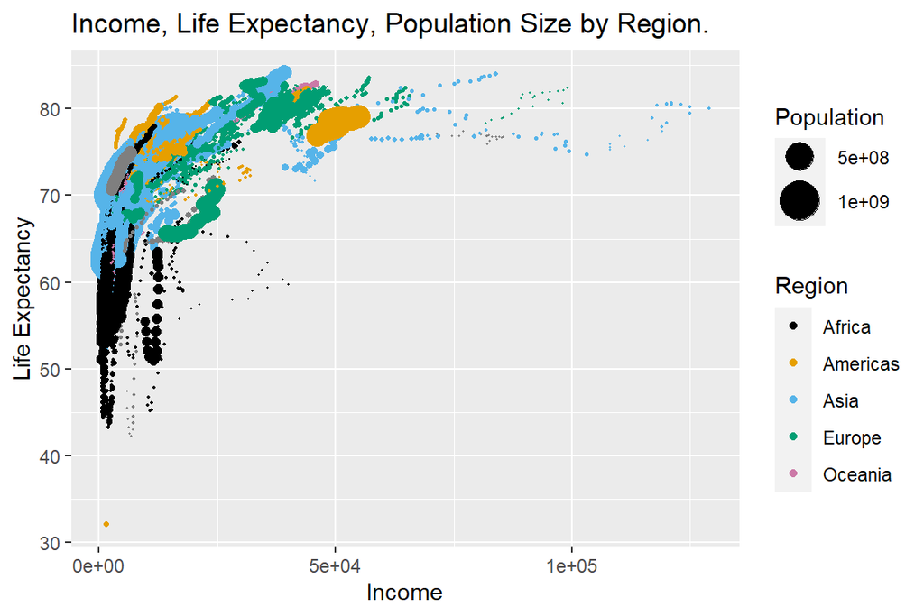

```r
data = read.csv("2000data.csv", header = TRUE)
# Plot
gg <- ggplot(data, aes(x = Income, y = life_expectancy, color = region, size = population)) +
  # As Scatter
  geom_point() +
  # Label Accordingly +
  labs(x = "Income", y ="Life Expectancy", title="Income, Life Expectancy, Population Size by Region.") +
    # Set the colors based off species
  scale_color_manual(values = c("Africa" = "#000000", "Americas"="#E69F00", "Asia"="#56B4E9", "Europe"="#009E73", "Oceania"="#CC79A7")) +
  # Don't allow the scale to be too large.
  scale_size_continuous(range = c(0, 10)) +
  guides(color = guide_legend(title = "Region"), size = guide_legend(title = "Population"))

print(gg)
```

### 0.3.1 Narrative

Based off the above plot, it is shown that the Asian and European regions consistently have the highest life expectancy, while quite a few Asian countries make a lot of income per person.  
The income variable itself does seem to be correlated to the life expectancy in the very simple sense that the older people become, the higher the chance they will make more money then someone who is younger.  
The population size implies that smaller counties have a higher chance to live higher. I would be hesitant to believe this. Reason being with smaller population sizes, the data is more easily skewed than a country with a higher population.

I.e., *small sample sizes could be biasing the experiment.*  
It’s also interesting to note that, while Africa does have a good size population and consistent income, their life expectancy is much lower than the other regions.  
There are a few outliers on the right hand side of the graph which make the visualization harder to analyze. If this were a real world presentation, I would remove those data points and document that I did so because those data points don’t seem to influence any correlation (aside to the obvious – that some people from the Asia region make a lot of money).